# Pot Survey – June 2023

June 5 - 7, 2023 *F/V Integrity* West Ocean City, MD

Author

Mike O’Brien (UMCES)

[interactive chart not shown]

## Packing list

🔲 Large cooler

🔲 Sampling bags and bag tags

🔲 Data sheets/clipboard

🔲 >2 fish pots

🔲 Two kill buckets

🔲 GPS

🔲 HOBO loggers (2)

🔲 MS222

🔲 Measuring board

🔲 Weight bucket with scales

🔲 2 fish totes

🔲 2 ropeless pots

## Participants

### June 5-7

- Dave Secor: 301-481-5053
- Mike O’Brien: 267-970-1973

### June 6-7

- Dave Secor
- Mike O’Brien
- Capt. Brandon Harrington
- *Integrity* mate

## Schedule

### 5 June

Scientific crew (MOB, DS)

- 0800 - 0900 MOB pack CBL truck (2017 Silverado) at Solomons, MD. Drive to Harry S Truman Park and Ride.
  - 200 Harry S. Truman Pkwy, Annapolis, MD 21401
- 1015 - 1230 MOB picks up LR. Drive to MD Coastal Bays Program office.
  - 8219 Stephen Decatur Hwy, Berlin, MD 21811
- 1230 - 1250 Load pots and two rope drums onto trailer.
- 1250 - 1300 Drive to Sea Born LLC.
  - 12906 Sunset Ave, Ocean City, MD 21842

Full crew (MOB, DS, BH, mate)

- 1300 - 1330 Unload pots. KH/mate begin loading pots onto vessel.
- 1330 - 1530 DHS/MOB drive to MD Coastal Bays Program. Repeat pot loading/return/unloading.
- 1530 - 1600 Drop trailer off at MDCBP. Return to W Ocean City.
- 1600 - 1800 Finish rigging ground line.
- 1800 Check into Microtel
  - 12536 Ocean Gateway, Ocean City, MD 21842

### June 06

Scientific & Sea Born crew

- 02:30 Meet at *F/V Integrity*
- 03:00 Depart OCMD for **C2306-1**
- **38 11.0654, -74 50.397**
- 04:55 Arrive **C2306-1**. Deploy pots.
- 05:05 Finish deploying pots. Depart for **C2306-2**
- **38 12.4933, -74 42.0976**
- 06:00 Arrive **C2306-2**. Deploy pots.
- 06:10 Finish deploying pots. Depart for **O12**
- **38 16.1313, -74 39.0571**
- 06:45 Arrive **O12**. Deploy pots.
- 06:55 Finish deploying pots. Depart for **P12**
- **38 16.1284, -74 38.0799**
- 07:05 Arrive **P12**. Deploy pots.
- 07:15 Finish deploying pots. Depart for **K08**
- **38 20.1893, -74 42.3134**
- 07:55 Arrive **K08**. Deploy pots.
- 08:05 Finish deploying pots. Depart for **J11**
- **38 17.1557, -74 43.7804**
- 08:30 Arrive **J11**. Deploy pots.
- 08:40 Finish deploying pots. Depart for **OCMD**
- 10:55 Arrive **OCMD**

Scientific crew picks up dry ice from Harris Teeter

- 31221 Americana Pkwy, Selbyville, DE 19975

### June 07

Scientific & Sea Born crew

- 02:30 Meet at *F/V Integrity*
- 03:00 Depart OCMD for **C2306-1**
- 04:55 Arrive **C2306-1**. Deploy pots.
- 05:10 Finish deploying pots. Depart for **C2306-2**
- 06:05 Arrive **C2306-2**. Deploy pots.
- 06:20 Finish deploying pots. Depart for **O12**
- 06:55 Arrive **O12**. Deploy pots.
- 07:10 Finish deploying pots. Depart for **P12**
- 07:20 Arrive **P12**. Deploy pots.
- 07:35 Finish deploying pots. Depart for **K08**
- 08:15 Arrive **K08**. Deploy pots.
- 08:30 Finish deploying pots. Depart for **J11**
- 08:55 Arrive **J11**. Deploy pots.
- 09:10 Finish deploying pots. Depart for **OCMD**
- 11:25 Arrive **OCMD**
- 11:45 Pick up trailer from MD Coastal Bays Program
- 12:00 Remove pots from F/V Integrity, load onto trailer. Unload at MD Coastal Bays program. Repeat as needed.

13:25 Scientific crew drive back to Solomons, MD

## Distances

Distance, nautical miles

|  | OCMD | C2306-1 | C2306-2 | J11 | K08 | P12 | O12 |
| --- | --- | --- | --- | --- | --- | --- | --- |
| OCMD | 0.00 | 15.10 | 20.24 | 17.78 | 18.76 | 22.36 | 21.60 |
| C2306-1 | 15.10 | 0.00 | 6.68 | 8.01 | 11.12 | 10.93 | 10.25 |
| C2306-2 | 20.24 | 6.68 | 0.00 | 4.85 | 7.70 | 4.82 | 4.35 |
| J11 | 17.78 | 8.01 | 4.85 | 0.00 | 3.25 | 4.59 | 3.85 |
| K08 | 18.76 | 11.12 | 7.70 | 3.25 | 0.00 | 5.25 | 4.80 |
| P12 | 22.36 | 10.93 | 4.82 | 4.59 | 5.25 | 0.00 | 0.77 |
| O12 | 21.60 | 10.25 | 4.35 | 3.85 | 4.80 | 0.77 | 0.00 |

Distance, time at 8 kts

|  | OCMD | C2306-1 | C2306-2 | J11 | K08 | P12 | O12 |
| --- | --- | --- | --- | --- | --- | --- | --- |
| OCMD | - | 01 h 55 m | 02 h 35 m | 02 h 15 m | 02 h 25 m | 02 h 50 m | 02 h 45 m |
| C2306-1 | 01 h 55 m | - | 00 h 55 m | 01 h 05 m | 01 h 25 m | 01 h 25 m | 01 h 20 m |
| C2306-2 | 02 h 35 m | 00 h 55 m | - | 00 h 40 m | 01 h 00 m | 00 h 40 m | 00 h 35 m |
| J11 | 02 h 15 m | 01 h 05 m | 00 h 40 m | - | 00 h 25 m | 00 h 35 m | 00 h 30 m |
| K08 | 02 h 25 m | 01 h 25 m | 01 h 00 m | 00 h 25 m | - | 00 h 40 m | 00 h 40 m |
| P12 | 02 h 50 m | 01 h 25 m | 00 h 40 m | 00 h 35 m | 00 h 40 m | - | 00 h 10 m |
| O12 | 02 h 45 m | 01 h 20 m | 00 h 35 m | 00 h 30 m | 00 h 40 m | 00 h 10 m | - |

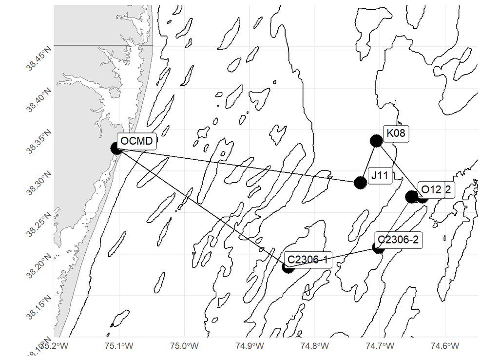